# Marine Ecological Modelling Global Climate Change

Jorge Assis, PhD // Centre of Marine Sciences, University of Algarve

## Model evaluation

## Model evaluation without cross-validation

Model evaluation computed only with the training dataset.

```
## [1] "All packages are correctly installed and loaded"
```

```r
# read records
presences <- read.csv("Data/dataBases/Paramuricea_clavata.csv",sep=";")
presences <- presences[,c("Lon","Lat")]

# load layers of sea surface temperatures
envCond <- load_layers(c("BO2_tempmin_bdmean","BO2_tempmax_bdmean"))

# crop layers to the European extent
europeanExtent <- extent(-15, 40, 25, 50)
envCond <- crop(envCond,europeanExtent)

# generate pseudo absences
absences <- pseudoAbsences(envCond,presences,n=10000)
```

S7 // Predictive performance in Ecological Modelling

```r
# extract environmental values and make a data.frame with PA information
modelData <- prepareModelData(presences,absences,envCond)

# fit a BRT model to the dataset
model <- train("BRT", modelData, folds = NULL )

# determine threshold dependent indices (assumes 0.5)
getAccuracy(model)
```

```
##   threshold       tss sensitivity specificity
## 1       0.5 0.2208172   0.2212389   0.9995783
```

S7 // Predictive performance in Ecological Modelling

```r
# The effect of threshold in threshold dependent indices
#
# Low threshold retrieves high sensitivity
getAccuracy(model,threshold = 0.00001)
```

```
##   threshold tss sensitivity specificity
## 1     1e-05   0           1           0
```

```r
# High threshold retrieve low sensitivity
getAccuracy(model,threshold = 0.99999)
```

```
##   threshold tss sensitivity specificity
## 1   0.99999   0           0           1
```

S7 // Predictive performance in Ecological Modelling

```r
# determine the threshold maximizing the sum of sensitivity and specificity
threshold <- thresholdMaxTSS(model)
```

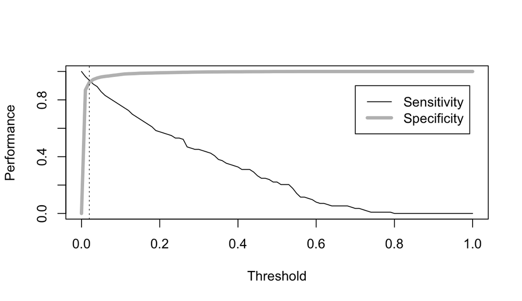

```r
threshold
```

```
## [1] 0.02
```

S7 // Predictive performance in Ecological Modelling

```r
# determine model performance
getAccuracy(model,threshold = threshold)
```

```
##   threshold       tss sensitivity specificity
## 1      0.02 0.8610895   0.9380531   0.9230364
```

S7 // Predictive performance in Ecological Modelling

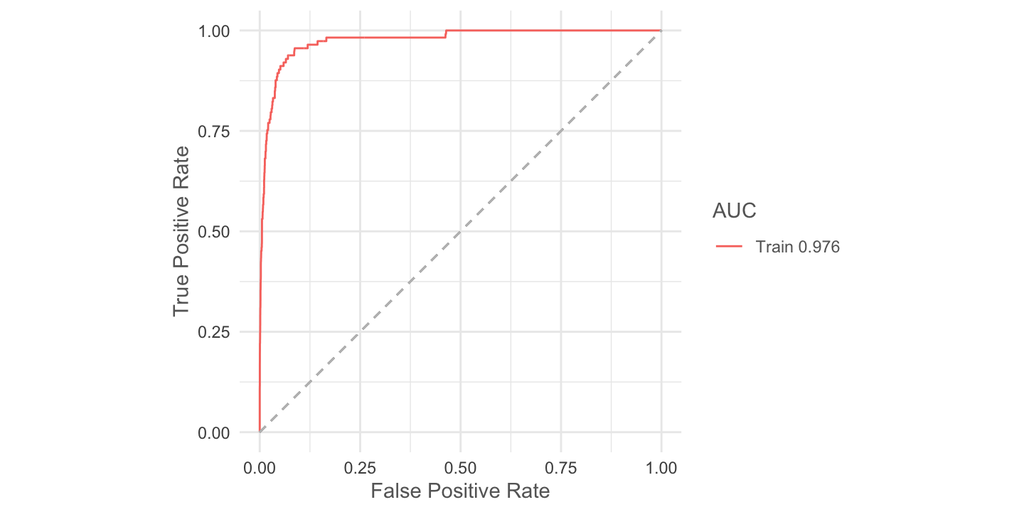

```r
# plot the threshold-independent Receiver operating characteristic
plotROC(model)
```

```r
# determine the threshold-independent AUC
getAUC(model)
```

```
## [1] 0.9756514
```

S7 // Predictive performance in Ecological Modelling

### Challenge 7.1

The main objective of this challenge is to **fit** a BRT model and assess its **predictive performance** with AUC without cross-validation.

**Packages, data and functions to accomplish the challenge:**

source(“sourceFunctions.R”)  
list_layers(datasets = “Bio-ORACLE”)  
read.csv(path)  
crop(object)  
pseudoAbsences(object)  
prepareModelData(object)  
train(object)  
plotROC(object)  
getAUC(object)

S7 // Predictive performance in Ecological Modelling

## Model evaluation with cross-validation

Model evaluation computed with a proper test dataset.

```r
# Cross validation with random partitioning of 10 folds
folds <- randomFolds(modelData, k = 10)

# fit a BRT model to the dataset
model <- train("BRT", modelData, folds = folds )

# determine AUC
getAUC(model, test = TRUE)
```

```
## [1] 0.9526462
```

S7 // Predictive performance in Ecological Modelling

```r
# Cross validation with 4 blocks partitioning [getBlocks !]
folds2 <- getBlocks(modelData)

# fit a BRT model to the dataset
model <- train("BRT", modelData, folds = folds2 )

# determine AUC
getAUC(model, test = TRUE)
```

```
## [1] 0.930211
```

S7 // Predictive performance in Ecological Modelling

### Challenge 7.2

The main objective of this challenge is to **fit** a BRT model and assess its **predictive performance** with AUC and cross-validation.

**Packages, data and functions to accomplish the challenge:**

source(“sourceFunctions.R”)  
list_layers(datasets = “Bio-ORACLE”)  
read.csv(path)  
crop(object)  
pseudoAbsences(object)  
prepareModelData(object)  
getBlocks(object)  
train(object)  
plotROC(object)  
getAUC(object)

S7 // Predictive performance in Ecological Modelling

## Reclassify predictive models

Use threshold dependent model evaluation to reclassify predictive surfaces

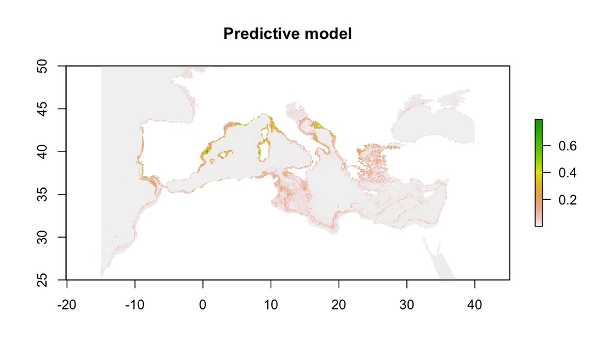

```r
# predict with BRT to raster stack
map <- predict(model, envCond, type=c("logistic"))
plot(map, main="Predictive model")
```

S7 // Predictive performance in Ecological Modelling

```r
# determine the threshold maximizing the sum of sensitivity and specificity
threshold <- thresholdMaxTSS(model)
```

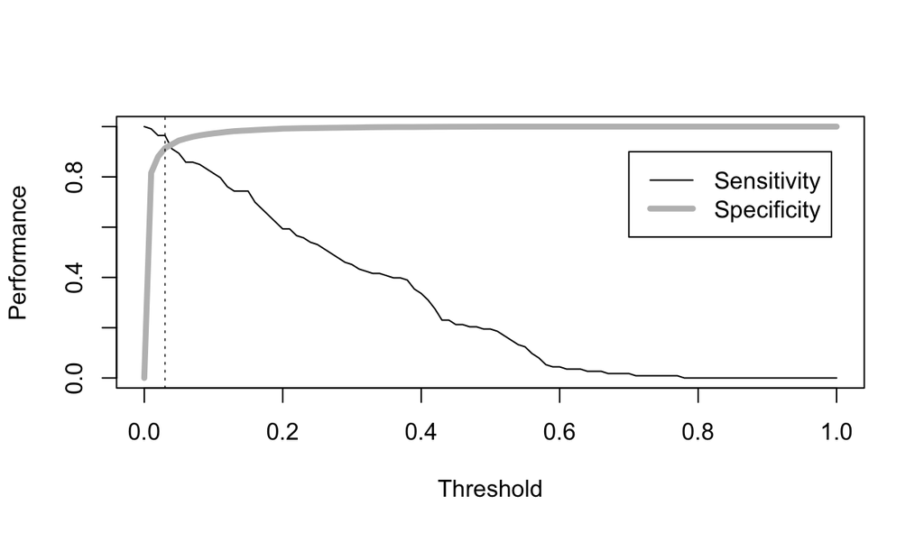

```r
threshold
```

```
## [1] 0.03
```

S7 // Predictive performance in Ecological Modelling

```r
# determine model performance
getAccuracy(model,threshold = threshold)
```

```
##   threshold       tss sensitivity specificity
## 1      0.03 0.8787821   0.9646018   0.9141803
```

```r
getAUC(model, test = TRUE)
```

```
## [1] 0.930211
```

```r
# generate a reclassification table
reclassMatrix <- data.frame(from = c(0,threshold) , to=c(threshold,1) , value=c(0,1))
reclassMatrix
```

```
##   from   to value
## 1 0.00 0.03     0
## 2 0.03 1.00     1
```

S7 // Predictive performance in Ecological Modelling

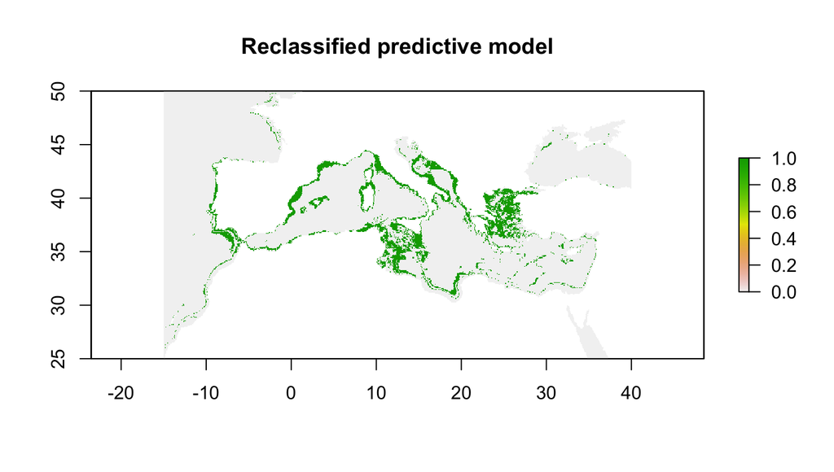

```r
# apply threshold to reclassify the predictive surface
map <- reclassify(map, rcl = reclassMatrix)
plot(map, main="Reclassified predictive model")
```

S7 // Predictive performance in Ecological Modelling

```r
# load layers of sea surface temperatures for the future
envCondRCP26 <- load_layers(c("BO2_RCP26_2100_tempmin_bdmean","BO2_RCP26_2100_tempmax_bdmean"))

# change layer names for them to match
names(envCondRCP26) <- c("BO2_tempmin_bdmean","BO2_tempmax_bdmean")

# crop layers to the European extent
envCondRCP26 <- crop(envCondRCP26,europeanExtent)

# predict with BRT to raster stack
mapRCP26 <- predict(model, envCondRCP26, type=c("logistic"))
```

S7 // Predictive performance in Ecological Modelling

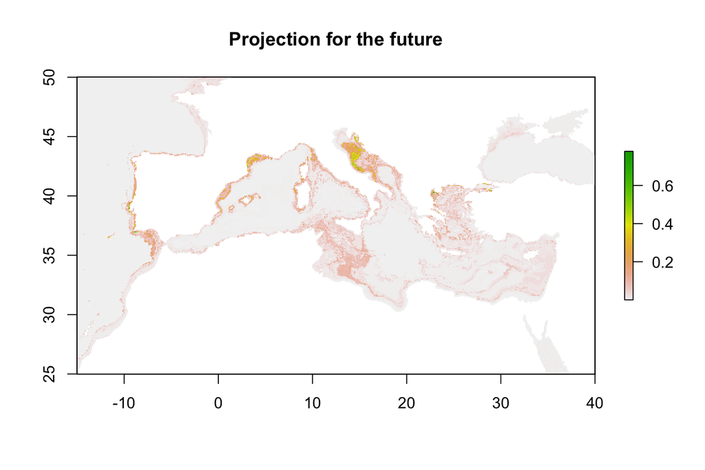

```r
plot(mapRCP26, main="Projection for the future")
```

S7 // Predictive performance in Ecological Modelling

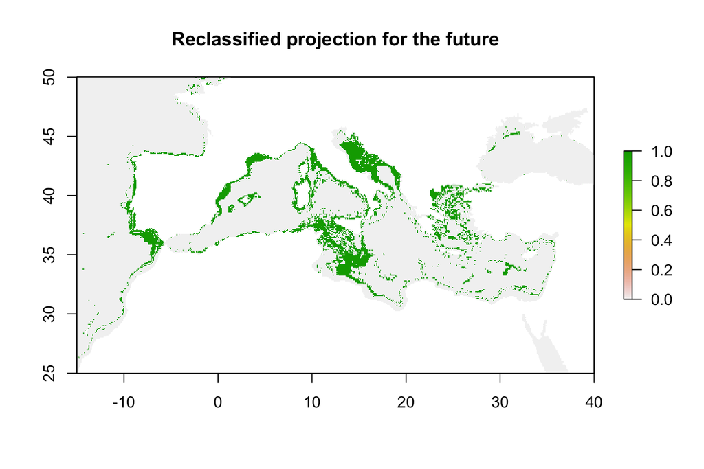

```r
# apply threshold to reclassify the future predictive surface
mapRCP26 <- reclassify(mapRCP26, rcl = reclassMatrix)
plot(mapRCP26, main="Reclassified projection for the future")
```

S7 // Predictive performance in Ecological Modelling

### Challenge 7.3

The main objective of this challenge is to **fit** a BRT model and **reclassify** a predictive surface (e.g., present) by using a threshold maximizing the sum of sensitivity and specificity.

**Packages, data and functions to accomplish the challenge:**

source(“sourceFunctions.R”)  
list_layers(datasets = “Bio-ORACLE”)  
read.csv(path)  
crop(object)  
pseudoAbsences(object)  
prepareModelData(object)  
get.block(object)  
train(object)  
thresholdMaxTSS(object)  
predict(object)  
data.frame(object)  
reclassify(object)  
plot(object)

S7 // Predictive performance in Ecological Modelling

## Variable relative importance and response curves

Inspecting variable relative importance and response curves to assess for ecological meaning in the models.

```r
# calculate the variable relative importance with permutations
viModel <- varImp(model, permut = 5)
viModel
```

```
##             Variable Permutation_importance    sd
## 1 BO2_tempmax_bdmean                  80.05 3.188
## 2 BO2_tempmin_bdmean                  19.95 3.188
```

S7 // Predictive performance in Ecological Modelling

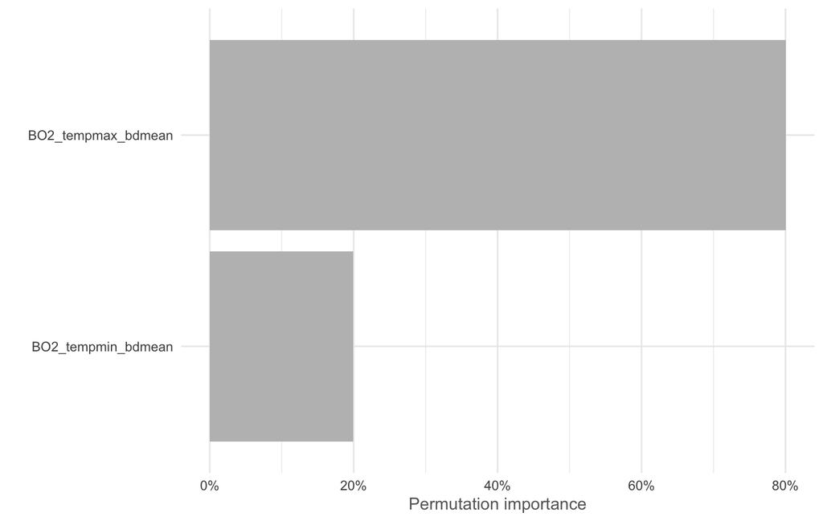

```r
plotVarImp(viModel)
```

S7 // Predictive performance in Ecological Modelling

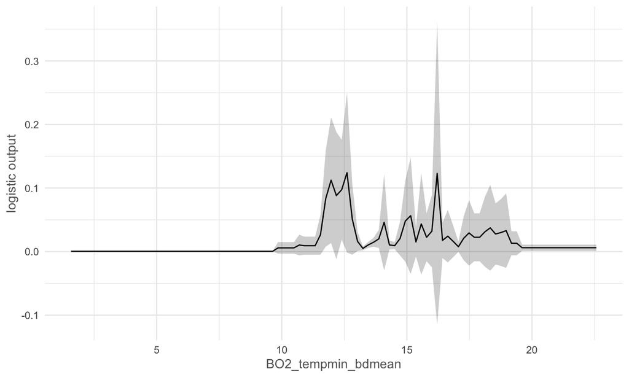

```r
# inspecting response curves
plotResponse(model, var = "BO2_tempmin_bdmean", type = "logistic", color="Black")
```

S7 // Predictive performance in Ecological Modelling

### Challenge 7.4

The main objective of this challenge is to **evaluate** a model by inspecting variable relative importance and response curves.

**Packages, data and functions to accomplish the challenge:**

source(“sourceFunctions.R”)  
list_layers(datasets = “Bio-ORACLE”)  
read.csv(path)  
crop(object)  
pseudoAbsences(object)  
prepareModelData(object)  
get.block(object)  
train(object)  
varImp(object)  
plotVarImp(object)  
plotResponse(object)

S7 // Predictive performance in Ecological Modelling

## References

Global change impacts on biodiversity. Available at: https://damariszurell.github.io/HU-GCIB

Copyright (c) Earth Lab. Available at: https://www.earthdatascience.org.

Open Science for Synthesis: Gulf Research Program Workshop. Available at: https://github.com/NCEAS/oss-lessons

Gimond, M. (2019) Intro to GIS and Spatial Analysis. Available at: https://mgimond.github.io/Spatial/